# plomics

A collection of functions for placental DNA methylation analysis.

- Install
  - lmmatrix
  - pairTest
  - findsentrix

## Install

```r
remotes::install_github('wvictor14/plomics')
```

## Functions

### lmmatrix

Computes pairwise linear models between several variables.

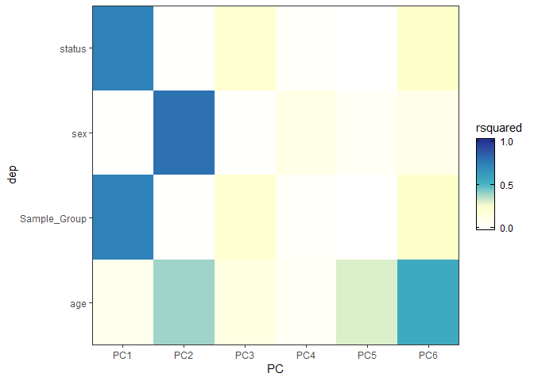

```r
library(minfiData)
library(plomics)

# load example data
data(RGsetEx)

# calculate pcs on the data
betas <- getBeta(RGsetEx)
pc_obj <- prcomp(t(na.omit(betas)), center = T, scale = T)

# get pc scores for each sample
rotated <- pc_obj$x

#rsquared
rsq <- lmmatrix(dep = rotated,
                ind = as.data.frame(pData(RGsetEx)[,c('Sample_Group', 'age', 'sex', 'status')]))

#pvalue
pva <- lmmatrix(dep = rotated,
                ind = as.data.frame(pData(RGsetEx)[,c('Sample_Group', 'age', 'sex', 'status')]),
                metric = 'Pvalue')
##### plot
# reshape first
rsq_plot <- rsq %>% as.data.frame() %>%

  # add dep variables
  mutate(dep = rownames(rsq)) %>%

  # reshape
  gather(PC, rsquared, -dep)

pva_plot <- pva %>% as.data.frame() %>%

  # add dep variables
  mutate(dep = rownames(rsq)) %>%

  # reshape
  gather(PC, pval, -dep) %>%

  # pvalue categories
  mutate(pval_cat = case_when(
    pval > 0.05  ~ '> 0.05',
    pval < 0.05 & pval > 0.01 ~ '< 0.05',
    pval < 0.01 & pval > 0.001 ~ '< 0.01',
    pval < 0.001 ~ '< 0.001'
  ))

ggplot(rsq_plot, aes(x = PC, y = dep, fill = rsquared)) +
  geom_tile() + theme_bw() +
  scale_x_discrete(expand = c(0, 0)) +
  scale_y_discrete(expand = c(0, 0)) +
  scale_fill_gradientn(colours=c("white", "#ffffcc", "#41b6c4", "#2c7fb8", "#253494"),
                       breaks = c(0,0.5,1), limits = c(0,1),
                       guide = guide_colorbar(frame.colour = "black", ticks.colour = "black"))
```

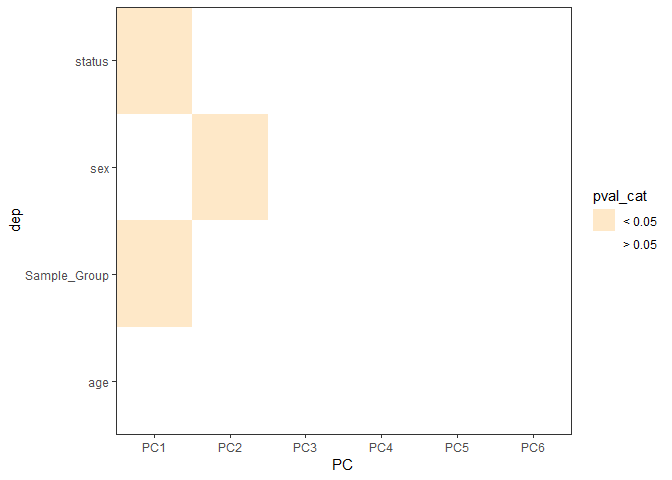

```r
ggplot(pva_plot, aes(x = PC, y = dep, fill = pval_cat)) +
  geom_tile() + theme_bw() +
  scale_x_discrete(expand = c(0, 0)) +
  scale_y_discrete(expand = c(0, 0)) +
  scale_fill_manual(values = c('> 0.05' = 'white', '< 0.05' = '#fee8c8',
                               '< 0.01' = '#fdbb84', '< 0.001' = '#e34a33'))
```

### pairTest

To test if covariates are confounding each other, we need to pairwise tests of independence between covariates. If at least one covariate is numeric, we can use linear regression. Otherwise if both covariates are categorical, then a chi squared test must be used.

```r
variables <- data.frame(
  row = c(1, 1, 2, 2, 3, 3),
  column = c(1, 1, 1, 2, 2, 2),
  Sex = c('m', 'm', 'm', 'f', 'f', 'f'),
  age = c(18, 19, 18, 27, 30, 16),
  ethnicity = c('AF', 'AF', 'AF', 'EU', 'EU', 'AS')
)

tests <- pairtest(variables)
# make categories
tests <- tests %>%
  mutate(pval_cat = if_else(p.value < 0.001, '< 0.001',
                            if_else(p.value < 0.01, '< 0.01',
                                    if_else(p.value < 0.05, '< 0.05', '<1'))))
tests
```

| X1 | Row | Column | Fstat | df | p.value | Chi.Square | pval_cat |
| --- | --- | --- | --- | --- | --- | --- | --- |
| 1 | row | column | 8.000000e+00 | 4 | 0.047 | NA | < 0.05 |
| 2 | row | Sex | 8.000000e+00 | 4 | 0.047 | NA | < 0.05 |
| 3 | row | age | 5.660000e-01 | 4 | 0.494 | NA | <1 |
| 4 | row | ethnicity | 3.643000e+00 | 3 | 0.104 | NA | <1 |
| 5 | column | Sex | 1.030218e+31 | 4 | 0.000 | NA | < 0.001 |
| 6 | column | age | 1.976000e+00 | 4 | 0.233 | NA | <1 |
| 7 | column | ethnicity | 7.605904e+30 | 3 | 0.000 | NA | < 0.001 |
| 8 | Sex | age | 1.976000e+00 | 4 | 0.233 | NA | <1 |
| 9 | Sex | ethnicity | NA | 2 | 0.050 | 6 | <1 |
| 10 | age | ethnicity | 4.591900e+01 | 3 | 0.221 | NA | <1 |

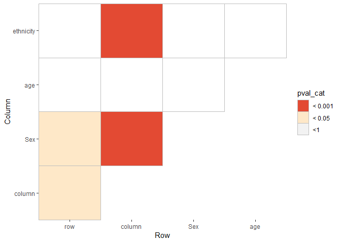

```r
# plot heatmap of associations
ggplot(tests, aes(x=Row, y = Column, fill = pval_cat)) +
  geom_tile(col = 'grey') + theme(panel.background = element_blank()) +
  scale_x_discrete(expand = c(0, 0)) +
  scale_y_discrete(expand = c(0, 0)) +
  scale_fill_manual(values = c('> 0.05' = 'white', '< 0.05' = '#fee8c8',
                               '< 0.01' = '#fdbb84', '< 0.001' = '#e34a33'))
```

### findsentrix

`findsentrix` takes a vector of sentrix IDs (chip identifiers) and searches a directory for IDAT files that match. The returned data frame contains two columns: (1) the sentrix ID (2) unique file paths for each idat that matches the sentrix ID.

Here is an example using the robinson lab master sample sheet:

```r
# read in master sample sheet
ss <- readxl::read_xlsx('Z:/ROBLAB6 Infinium450k John/Master_Sample_Sheet.xlsx')

## specify idat directory
idat_dir <- 'Z:/ROBLAB6 Infinium450k John/EPIC Raw data/'

ss <- ss %>%

# Take the first 6 EPIC samples
  dplyr::arrange(desc(Platform)) %>%
  dplyr::slice(1:6) %>%
  dplyr::select(Sample_Name, Sentrix_ID, Sentrix_Position) %>%

# create sentrix column
  dplyr::mutate(Sentrix = paste0(Sentrix_ID, '_', Sentrix_Position))
```

We created a sentrix ID by taking the chip serial number (confusingly named as “sentrix_ID”) and pasting this to the position identifier (“Sentrix_Position”):

**Sentrix:** 200889820007_R01C01

**Sentrix Chip Number:** 200889820007

**Sentrix Position on chip:** R01C01

Now we can use `findsentrix` to find the filepaths for idats that match each sentrix identifier:

```r
idatfiles <- findsentrix(sentrix = ss$Sentrix, directory = idat_dir)
idatfiles
```

| Sentrix | Basename |
| --- | --- |
| 200889820007_R01C01 | Z:/ROBLAB6 Infinium450k John/EPIC Raw data//Batch7_rescan/200889820007/200889820007_R01C01 |
| 200889820007_R02C01 | Z:/ROBLAB6 Infinium450k John/EPIC Raw data//Batch7_rescan/200889820007/200889820007_R02C01 |
| 200889820007_R03C01 | Z:/ROBLAB6 Infinium450k John/EPIC Raw data//Batch7_rescan/200889820007/200889820007_R03C01 |
| 200889820007_R04C01 | Z:/ROBLAB6 Infinium450k John/EPIC Raw data//Batch7_rescan/200889820007/200889820007_R04C01 |
| 200889820007_R05C01 | Z:/ROBLAB6 Infinium450k John/EPIC Raw data//Batch7_rescan/200889820007/200889820007_R05C01 |
| 200889820007_R06C01 | Z:/ROBLAB6 Infinium450k John/EPIC Raw data//Batch7_rescan/200889820007/200889820007_R06C01 |

```r
# join all matches, retaining unmatched and multiple matched IDs
ss <- ss %>%
  dplyr::full_join(idatfiles, by = 'Sentrix')
```

Finally, we can load idats using this dataframe:

```r
## Now you can load in these samples with minfi::read.metharray.exp
rgset <- minfi::read.metharray.exp(targets = as.data.frame(ss), verbose = T)
```

```
## [read.metharray] Reading 200889820007_R01C01_Grn.idat
```

```
## [read.metharray] Reading 200889820007_R02C01_Grn.idat
```

```
## [read.metharray] Reading 200889820007_R03C01_Grn.idat
```

```
## [read.metharray] Reading 200889820007_R04C01_Grn.idat
```

```
## [read.metharray] Reading 200889820007_R05C01_Grn.idat
```

```
## [read.metharray] Reading 200889820007_R06C01_Grn.idat
```

```
## [read.metharray] Reading 200889820007_R01C01_Red.idat
```

```
## [read.metharray] Reading 200889820007_R02C01_Red.idat
```

```
## [read.metharray] Reading 200889820007_R03C01_Red.idat
```

```
## [read.metharray] Reading 200889820007_R04C01_Red.idat
```

```
## [read.metharray] Reading 200889820007_R05C01_Red.idat
```

```
## [read.metharray] Reading 200889820007_R06C01_Red.idat
```

```
## [read.metharray] Read idat files in 2.5 seconds
```

```
## [read.metharray] Creating data matrices ... done in 10.8 seconds
## [read.metharray] Instantiating final object ... done in 0.1 seconds
```

```r
rgset
```

```
## class: RGChannelSet
## dim: 1052641 6
## metadata(0):
## assays(2): Green Red
## rownames(1052641): 1600101 1600111 ... 99810990 99810992
## rowData names(0):
## colnames(6): 200889820007_R01C01 200889820007_R02C01 ...
##   200889820007_R05C01 200889820007_R06C01
## colData names(6): Sample_Name Sentrix_ID ... Basename filenames
## Annotation
##   array: IlluminaHumanMethylationEPIC
##   annotation: ilm10b4.hg19
```